# Assign_1 Pallavi Ravikumar Menon (W0773763)

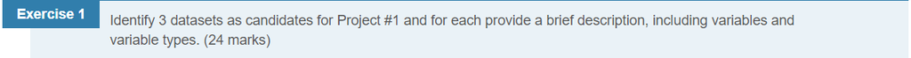

1)**Dataset 1 :** Source: https://www.kaggle.com/unsdsn/world-happiness

**Description:** **The world happiness dataset signifies the level of happiness across the globe. The data is framed and recorded strictly considering each country’s government and their respective policies withholding the happiness parameters. Highlighting with expertise of leading economists, psychologists, survey analysts and other health governing bodies, the dataset was drafted effectively to assess the progress of nations.**

```
  Variable        |   Variable Types
----------------- |---------------------
Country           |     Character
Region            |     Character
Happiness Rank    |     Integer
Happiness Score   |     Numeric
Standard Error    |     Numeric
GDP               |     Numeric
Family            |     Numeric
Health            |     Numeric
Freedom           |     Numeric
Trust             |     Numeric
Generosity        |     Numeric
Dystopia Residual |     Numeric
```

2)**Dataset 2 :** Source: https://www.kaggle.com/ruchi798/movies-on-netflix-prime-video-hulu-and-disney

**Description:** **The dataset consists comprehensive list of movies available on various OTT platforms along with IMDb rating from year (1902- 2020). It is really interesting as lot of data analytics can be performed on the datasets to understand “which streaming platform(s) a particular movie can be streamed?” as well as “ Average IMDb rating of movies country wise?”**

```
Variable        |   Variable Types
----------------|---------------------
Title           |     Character
Year            |     integer
Age             |     Integer
IMDb            |     Numeric
Rotten Tomatoes |     Numeric
Netflix         |     Integer
Hulu            |     Integer
prime Video     |     Integer
Disney +        |     Integer
Directors       |     Character
Genres          |     Character
Country         |     Character
Language        |     Character
Runtime         |     Interger
```

3) **Dataset 3:** Source: https://www.kaggle.com/uciml/pima-indians-diabetes-database

**Description:** **The dataset put up by National Institute of Diabetes and Digestive and Kidney Diseases displays various parameters in order to predict chances of diabetes among females from 21 years or older belonging to Pima Indian Heritage.**

```
Variable                   |   Variable Types
---------------------------|---------------------
Pregnancies                |     Integer
Glucose                    |     Integer
Blood Pressure             |     Integer
Skin thickness             |     Integer
Insulin                    |     Integer
BMI                        |     Numeric
Diabetes Pedigree Function |     Numeric
Age                        |     Integer
Outcome                    |     Integer
```

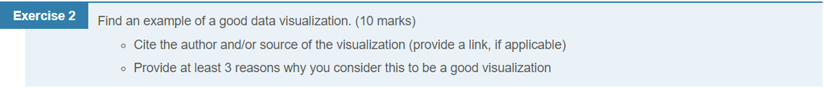

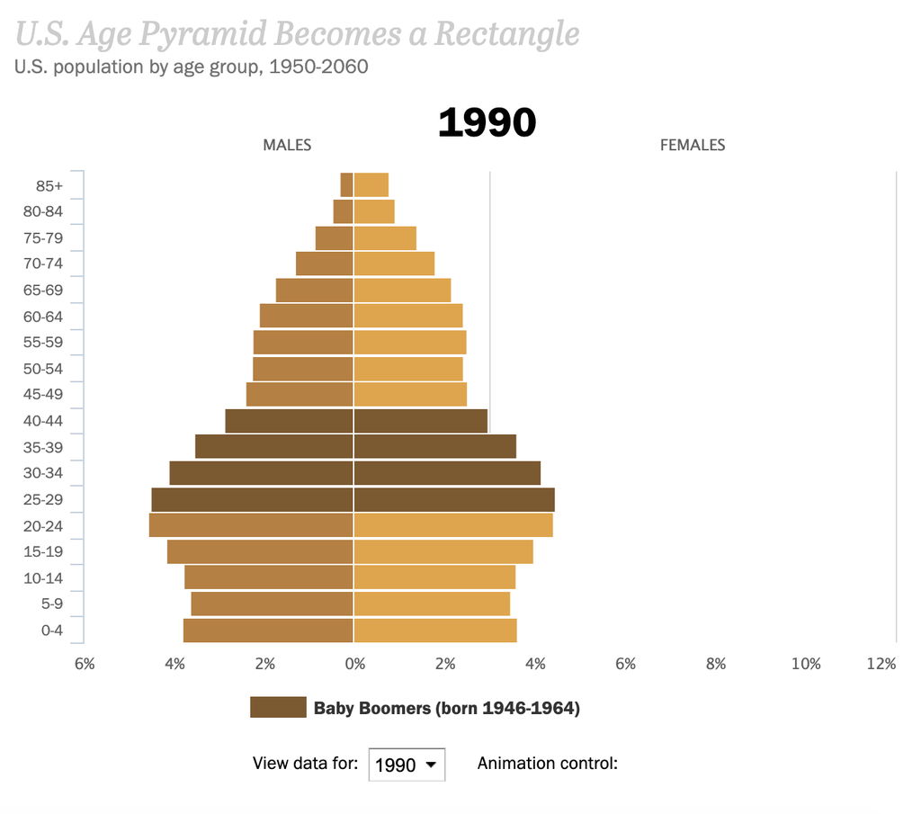

**I consider this good representation because of following reasons:**

```
i) The visualization is precise and intuitive for a novice having no prior knowledge of deriving conclusions from a graph.
ii) Also, the feature enabling to view data for particular year is displayed making it data driven graphical representation.
iii) Mutual color denoting “Baby Boomers” conveys group of people born post world war II in an era of increase in the birth rate. Overall, the colors used for indicating genders gives it a more readable and understandable approach.
```

Source : https://worldbestnews.info/the-power-of-data-visualization-plus-examples-of-good-and-bad-visuals/

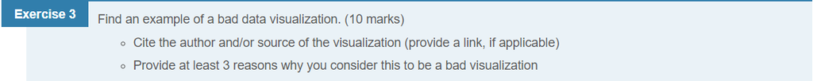

[figure not shown]

**I consider this bad representation because of following reasons:**

```
1)  The haphazard approach of implementation of this dataset seems like a vague attempt of complicating it more rather than simplifying it.
2)  The idea of this data is to derive a simplistic relation between the author and the genres of novel written by them. Instead of keeping a primary centric approach (i.e.Author with respect to genres or vice versa), the creator landed up muddling the entire data.
3)  The overuse of colors has contributed equally to the above-mentioned pointers.
```

Source : http://bloggotype.blogspot.com/2012/04/mapping-popular-story-plot-lines.html

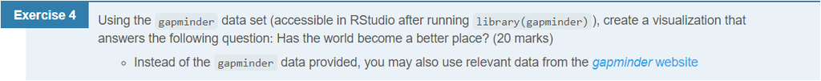

```r
library(tidyverse)
library(here)
```

```r
library(ggplot2)
library(gapminder)
gapminder::gapminder
```

| country | continent | year | lifeExp | pop | gdpPercap |
| --- | --- | --- | --- | --- | --- |
| Afghanistan | Asia | 1952 | 28.80100 | 8425333 | 779.4453 |
| Afghanistan | Asia | 1957 | 30.33200 | 9240934 | 820.8530 |
| Afghanistan | Asia | 1962 | 31.99700 | 10267083 | 853.1007 |
| Afghanistan | Asia | 1967 | 34.02000 | 11537966 | 836.1971 |
| Afghanistan | Asia | 1972 | 36.08800 | 13079460 | 739.9811 |
| Afghanistan | Asia | 1977 | 38.43800 | 14880372 | 786.1134 |
| Afghanistan | Asia | 1982 | 39.85400 | 12881816 | 978.0114 |
| Afghanistan | Asia | 1987 | 40.82200 | 13867957 | 852.3959 |
| Afghanistan | Asia | 1992 | 41.67400 | 16317921 | 649.3414 |
| Afghanistan | Asia | 1997 | 41.76300 | 22227415 | 635.3414 |

[output cut: 1694 more lines]

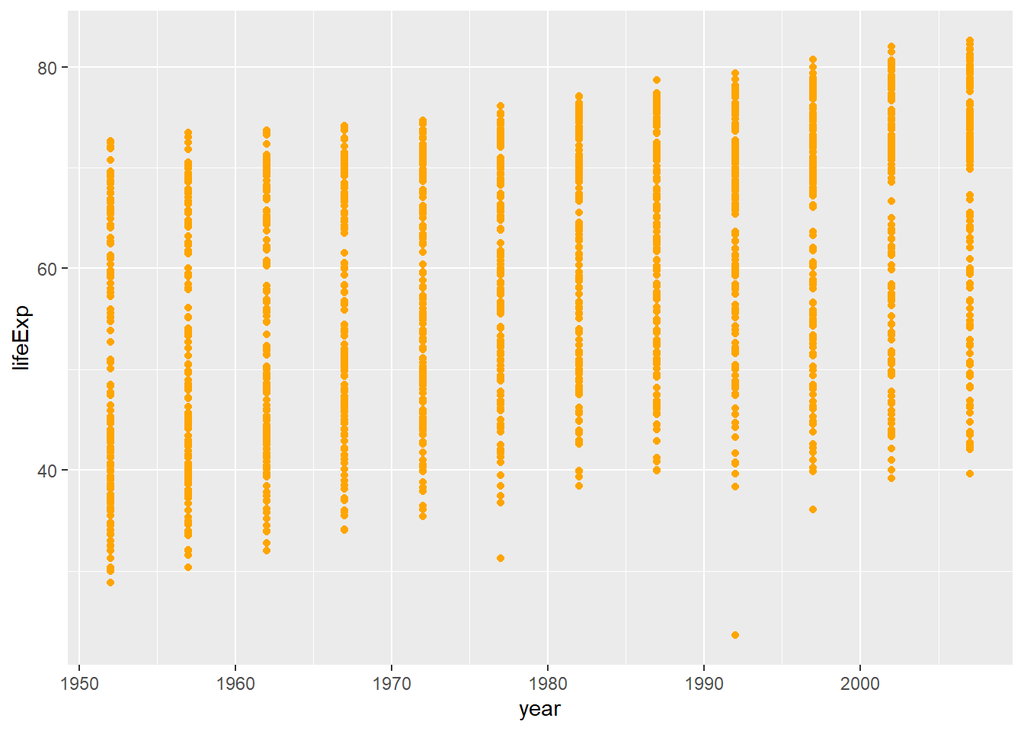

```r
ggplot(data = gapminder::gapminder) +
  geom_point(mapping= aes(x=year,y= lifeExp), color = "orange")
```

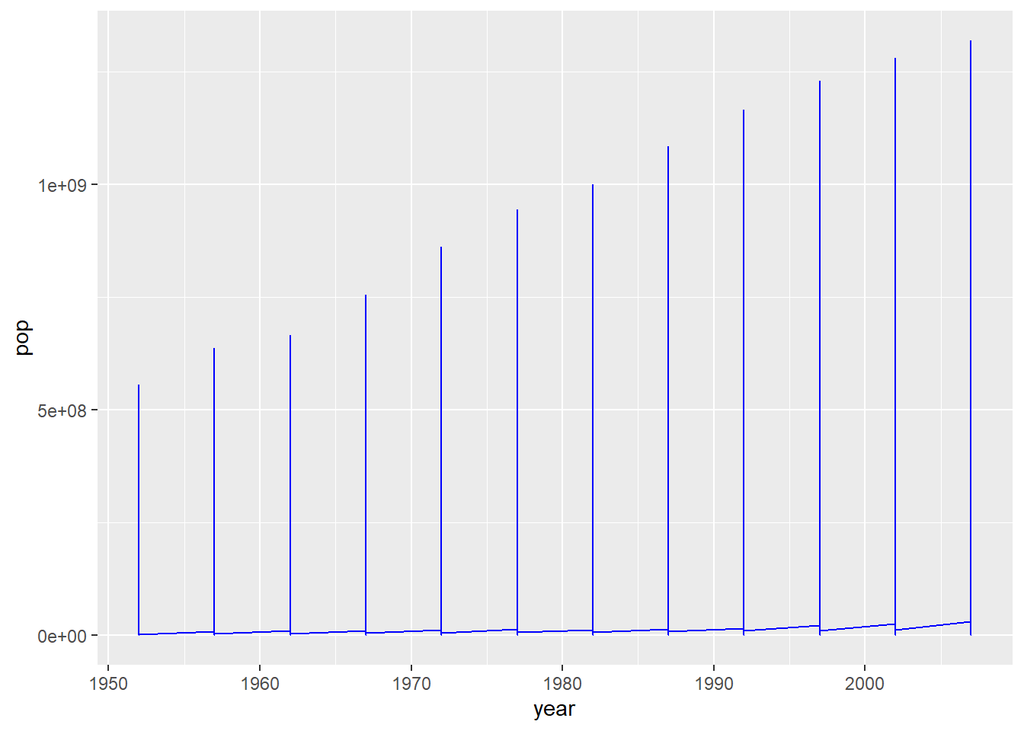

```r
ggplot(data = gapminder::gapminder) +
  geom_line(mapping= aes(x=year,y= pop), color = "blue")
```